# Create Model

### 19.2.1 가격과 캐럿

중요한 혼란 변수인 다이아몬드의 무게가 존재하기 때문에 품질이 낮은 다이아몬드가 가격이  
더 높은 것처럼 보인다. 다이아몬드의 무게는 가격을 결정하는 가장 중요한 요소이며  
품질이 낮은 다이아몬드가 더 무거운 경향이 있다

[figure not shown]

```r
ggplot(diamonds, aes(carat, price)) + geom_hex(bins = 50)
```

carat 항목을 분리해서 다이아몬드의 다른 속성이 상대적으로 가격에 어떤 영향을 주는지  
알 수 있다.  
먼저 작업하기 쉽게 아래 두가지 항목으로 다이아몬드 데이터셋을 변경해보자

**1. 2.5캐럿보다 작은 다이아몬드로 한정한다.**  
**2. 캐럿과 가격 변수를 로그 변환한다.**

```r
diamonds2 <- diamonds %>%
  filter(carat <= 2.5) %>%
  mutate(lprice = log2(price), lcarat = log2(carat))
```

또, 이렇게 변환함으로써 무게와 가격의 관계를 좀 더 알기 쉽게해준다

[figure not shown]

```r
ggplot(diamonds2, aes(lcarat, lprice)) + geom_hex(bins = 50)
```

로그 변환은 해당 패턴을 작업하기에 가장 쉬운 선형 패턴으로 만들어주기 때문에 매우 유용하다.  
다음으로 넘어가서 가장 강한 선형패턴을 제거해보자. 먼저 모델의 패턴을 명확하게 만든다.

```r
mod_diamond <- lm(lprice ~ lcarat, data = diamonds2)
```

다음, 모델이 데이터에 대해 말하는 내용을 살펴본다.  
예측값에 대해 로그 변환을 되돌리는 역변환을 적용하면 원 데이터에 예측값을 겹쳐 그릴 수 있다.

```r
grid <- diamonds2 %>%
  data_grid(carat = seq_range(carat, 20)) %>%
  mutate(lcarat = log2(carat)) %>%
  add_predictions(mod_diamond, "lprice") %>%
  mutate(price = 2 ^ lprice)
```

[figure not shown]

```r
ggplot(diamonds2, aes(carat, price)) +
  geom_hex(bins = 50) +
  geom_line(data = grid, color = "red", size = 1)
```

이 모델이 옳다면 크기가 큰 다이아몬드는 생각보다 싸다  
원인은 해당 데이터셋에 19000달러가 넘는 다이아몬드가 없는게 이유일 것이다  
이제 강한 선형 패턴을 제대로 제거했는지 확인해보자

```r
diamonds2 <- diamonds2 %>%
  add_residuals(mod_diamond, "lresid")
```

[figure not shown]

```r
ggplot(diamonds2, aes(lcarat, lresid)) +
  geom_hex(bins = 50)
```

여기서 알 수 있는점은 가격 대신 lresid를 이용하여 문제가 되었던 플롯을 다시 그릴 수 있다는것이다

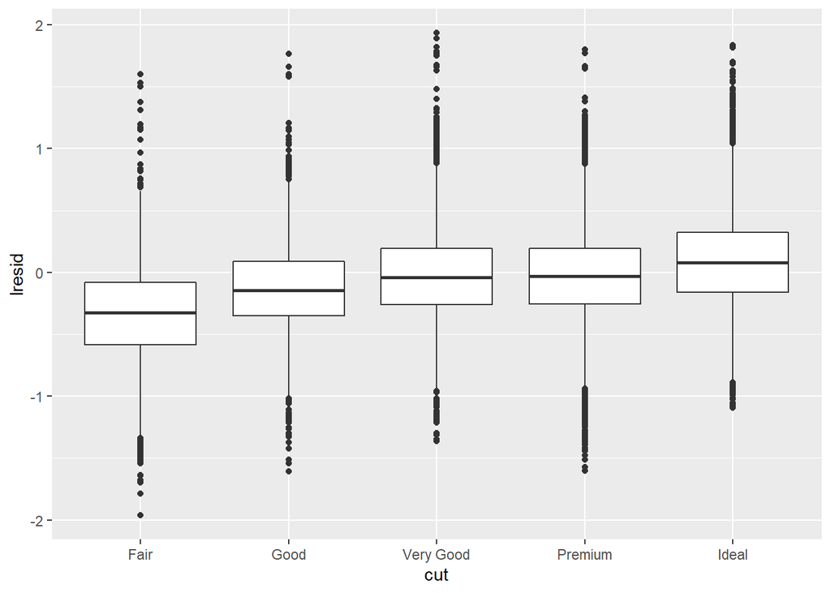

```r
ggplot(diamonds2, aes(cut, lresid)) + geom_boxplot()
```

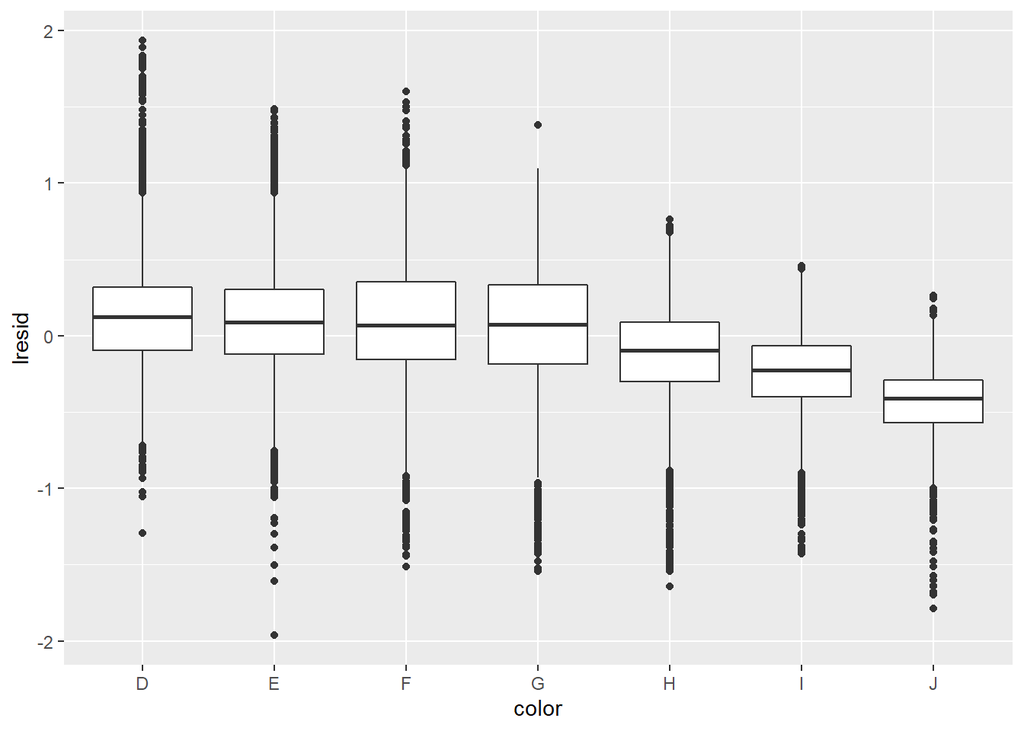

```r
ggplot(diamonds2, aes(color, lresid)) + geom_boxplot()
```

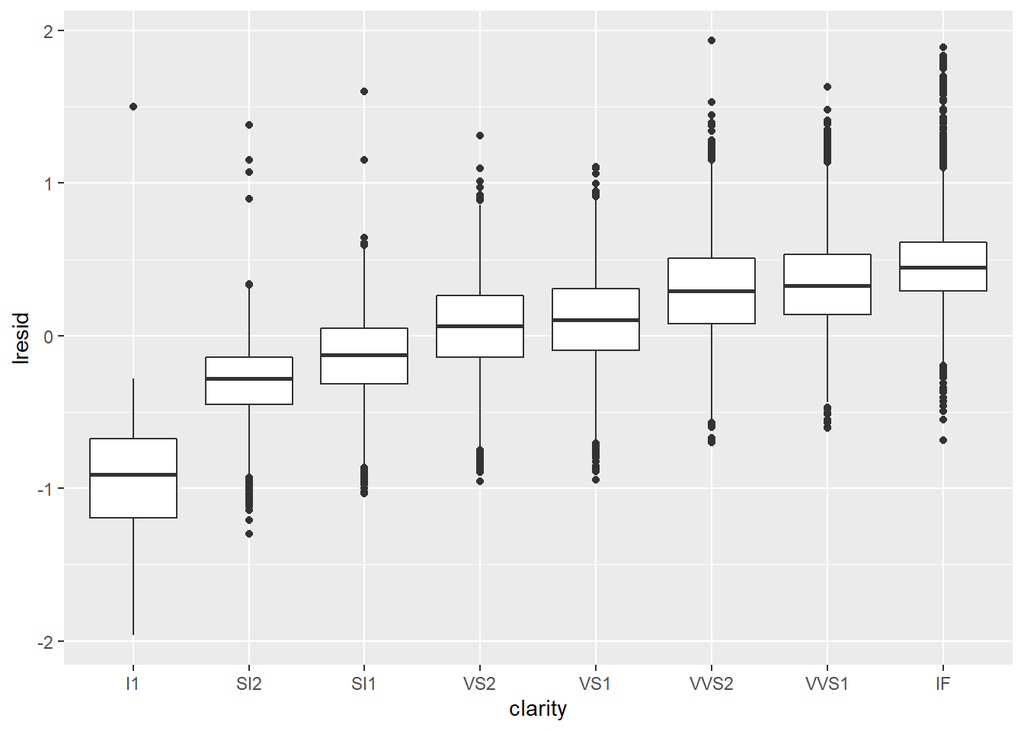

```r
ggplot(diamonds2, aes(clarity, lresid)) + geom_boxplot()
```

이제 가격과 커팅,색,투명도의 관계를 확인해보면 좋은 품질의 다이아몬드가 가격이 높아진것을 확인할 수 있다

### 19.2.2 더 복잡한 모델

원한다면 관측한 효과를 모델로 이동하여 모델을 발전시킬 수 있다  
예를들어 색, 커팅, 투명도를 모델에 포함하여 범주형 변수의 효과를 나타낼 수 있다

```r
mod_diamond2 <- lm(lprice ~ lcarat + color + cut + clarity, data = diamonds2)
```

모델에 네가지 예측변수가 모두 포함되었다.  
이제 시각화는 좀 더 어려워지겠지만 모든 변수가 독립적이므로 따로따로 그릴 수 있다.  
이 과정을 쉽게 만들기 위해 data_grid 함수에 .model 인수를 사용할 것이다

```r
grid <- diamonds2 %>%
  data_grid(cut, .model = mod_diamond2) %>%
  add_predictions(mod_diamond2)
grid
```

```
## # A tibble: 5 x 5
##   cut       lcarat color clarity  pred
##   <ord>      <dbl> <chr> <chr>   <dbl>
## 1 Fair      -0.515 G     VS2      11.2
## 2 Good      -0.515 G     VS2      11.3
## 3 Very Good -0.515 G     VS2      11.4
## 4 Premium   -0.515 G     VS2      11.4
## 5 Ideal     -0.515 G     VS2      11.4
```

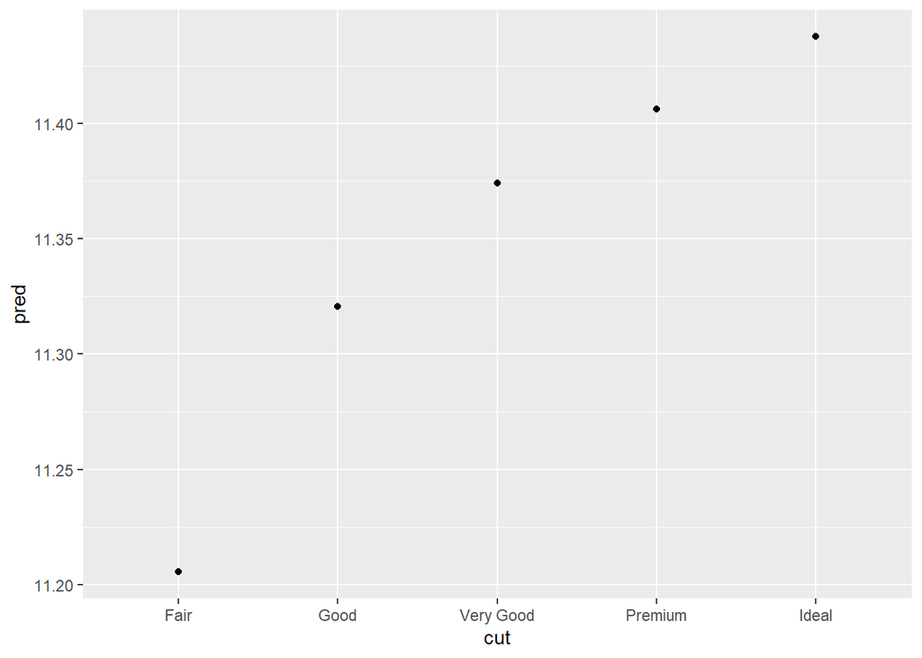

```r
ggplot(grid, aes(cut, pred)) + geom_point()
```

명시적으로 제공되지 않은 변수를 모델이 필요로 한다면 data_grid() 함수가 자동으로  
‘대표적인’ 값으로 채울 것이다.  
**연속형 변수 > 중앙값**  
**범주형 변수 > 빈번한 값**

[figure not shown]

```r
diamonds2 <- diamonds2 %>%
  add_residuals(mod_diamond2, "lresid2")

ggplot(diamonds2, aes(lcarat, lresid2)) + geom_hex(bins = 50)
```

이 데이터는 값이 큰 다이아몬드가 일부 존재한다는 것을 보여준다  
값이2라는 것은 다이아몬드의 가격이 예상했던 가격의 4배라는 것을 나타낸다

```r
diamonds2 %>%
  filter(abs(lresid2) > 1) %>%
  add_predictions(mod_diamond2) %>%
  mutate(pred = round(2 ^ pred)) %>%
  select(price, pred, carat:table, x:z) %>%
  arrange(price)
```

```
## # A tibble: 16 x 11
##    price  pred carat cut       color clarity depth table     x     y     z
##    <int> <dbl> <dbl> <ord>     <ord> <ord>   <dbl> <dbl> <dbl> <dbl> <dbl>
##  1  1013   264 0.25  Fair      F     SI2      54.4    64  4.3   4.23  2.32
##  2  1186   284 0.25  Premium   G     SI2      59      60  5.33  5.28  3.12
##  3  1186   284 0.25  Premium   G     SI2      58.8    60  5.33  5.28  3.12
##  4  1262  2644 1.03  Fair      E     I1       78.2    54  5.72  5.59  4.42
##  5  1415   639 0.35  Fair      G     VS2      65.9    54  5.57  5.53  3.66
##  6  1415   639 0.35  Fair      G     VS2      65.9    54  5.57  5.53  3.66
##  7  1715   576 0.32  Fair      F     VS2      59.6    60  4.42  4.34  2.61
##  8  1776   412 0.290 Fair      F     SI1      55.8    60  4.48  4.41  2.48
##  9  2160   314 0.34  Fair      F     I1       55.8    62  4.72  4.6   2.6
## 10  2366   774 0.3   Very Good D     VVS2     60.6    58  4.33  4.35  2.63
## 11  3360  1373 0.51  Premium   F     SI1      62.7    62  5.09  4.96  3.15
## 12  3807  1540 0.61  Good      F     SI2      62.5    65  5.36  5.29  3.33
## 13  3920  1705 0.51  Fair      F     VVS2     65.4    60  4.98  4.9   3.23
## 14  4368  1705 0.51  Fair      F     VVS2     60.7    66  5.21  5.11  3.13
## 15 10011  4048 1.01  Fair      D     SI2      64.6    58  6.25  6.2   4.02
## 16 10470 23622 2.46  Premium   E     SI2      59.7    59  8.82  8.76  5.25
```

여기에서 분명하게 눈에 띄는 것은 없지만, 모델에 문제가 있는지 혹은 데이터에 오류가 있는지  
생각해보는데 시간을 투자할 가치가 있다.  
만약 데이터에 오류가 있다면 부정확하게 낮은 가격으로 가격이 매겨진 다이아몬드를 사게 될 수 도 있다.

### 19.3 일일 운항 횟수에 어떤 영향이 있는가?

더 간단해보이는 데이터셋에 대해 비슷한 과정을 진행해보자  
(뉴욕 비행기 데이터)

일자별 항공편의 빈도수를 ggplot으로 시각화 >

```r
daily <- flights %>%
  mutate(date = make_date(year, month, day)) %>%
  group_by(date) %>%
  summarize(n = n())
```

```r
daily
```

```
## # A tibble: 365 x 2
##    date           n
##    <date>     <int>
##  1 2013-01-01   842
##  2 2013-01-02   943
##  3 2013-01-03   914
##  4 2013-01-04   915
##  5 2013-01-05   720
##  6 2013-01-06   832
##  7 2013-01-07   933
##  8 2013-01-08   899
##  9 2013-01-09   902
## 10 2013-01-10   932
## # ... with 355 more rows
```

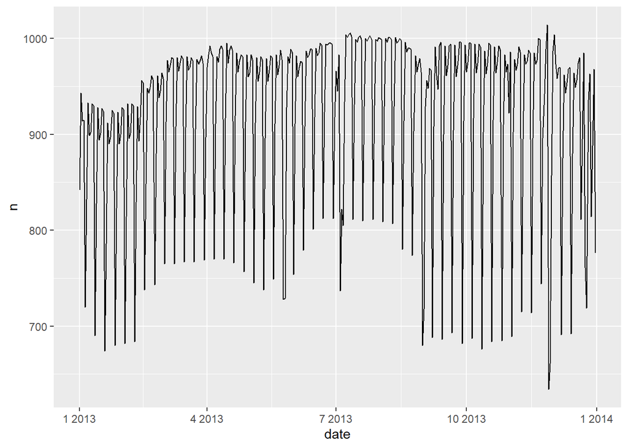

```r
ggplot(daily, aes(date, n)) + geom_line()
```

### 19.3.1 요일

요일효과가 매우 강하게 존재하기 때문에 장기적인 트렌드를 이해하기 쉽지 않다  
요일별 항공편의 수에 대한 분포를 먼저 살펴보자.

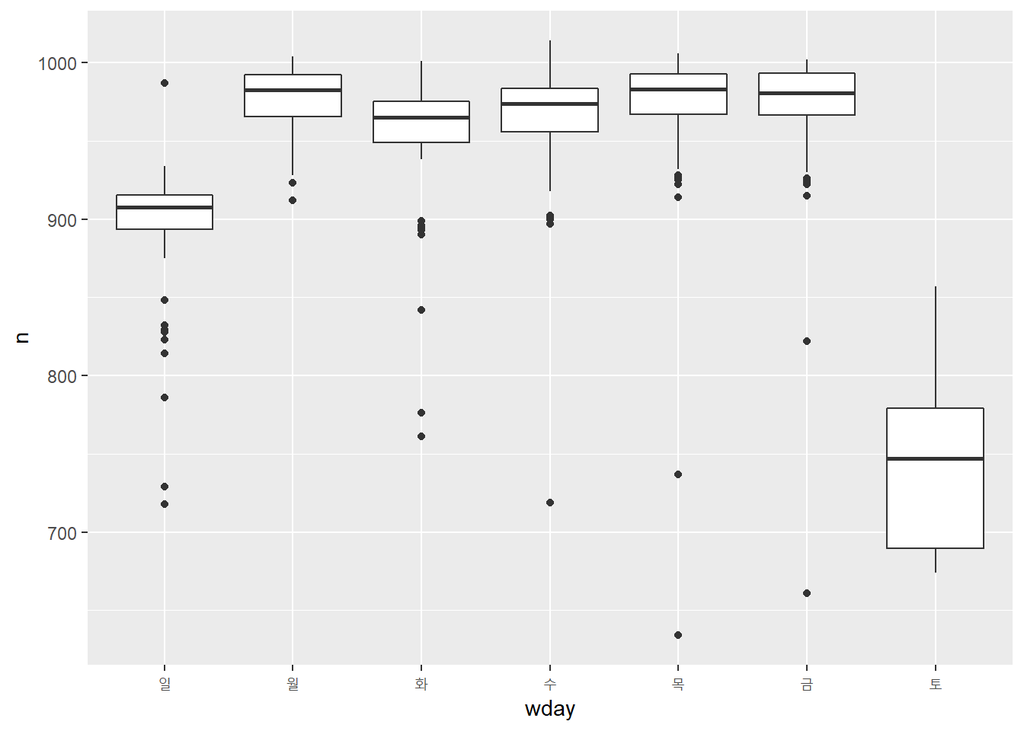

```r
daily <- daily %>%
  mutate(wday = wday(date, label = TRUE))
ggplot(daily, aes(wday, n)) + geom_boxplot()
```

평일에 이용수가 주말의 이용수보다 월등히 많은것을 알 수 있다.

이 패턴을 제거하는 한가지 방법은 모델을 사용하는 것이다.  
먼저 모델을 생성하고 원 데이터에 예측값을 겹쳐서 나타낸다.

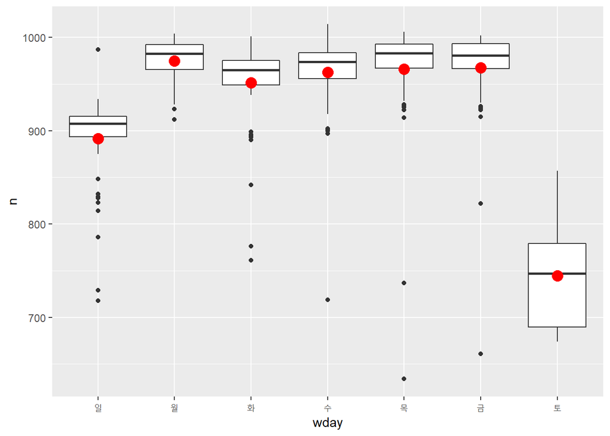

```r
mod <- lm(n ~ wday, data = daily)
grid <- daily %>%
  data_grid(wday) %>%
  add_predictions(mod, "n")

ggplot(daily, aes(wday, n)) + geom_boxplot() + geom_point(data = grid, color = "red", size = 4)
```

다음으로 잔차를 계산 후 시각화한다

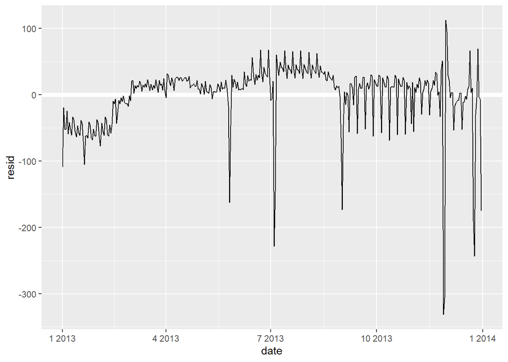

```r
daily <- daily %>%
  add_residuals(mod)
daily %>%
  ggplot(aes(date, resid)) + geom_ref_line(h = 0) + geom_line()
```

6월부분부터 그래프가 들쭉날쭉한것을 확인할 수 있다  
각 요일을 플룻으로 그려보면 알 수 있을것이다

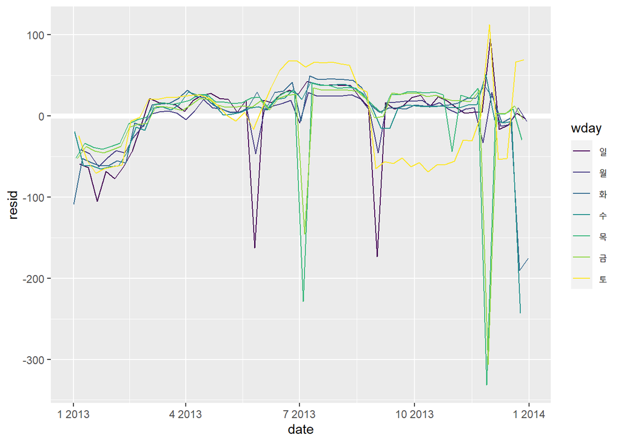

```r
ggplot(daily, aes(date, resid, color = wday)) + geom_ref_line(h = 0) + geom_line()
```

그래프를 보면 토요일의 그래프가 예측에서 차이가 난다  
여름에는 항공편이 예측값보다 많고 가을에는 적다  
이런 패턴을 포작하기 위해 더 나은 방법을 알아보면

```r
daily %>%
  filter(resid < -100)
```

```
## # A tibble: 11 x 4
##    date           n wday  resid
##    <date>     <int> <ord> <dbl>
##  1 2013-01-01   842 화    -109.
##  2 2013-01-20   786 일    -105.
##  3 2013-05-26   729 일    -162.
##  4 2013-07-04   737 목    -229.
##  5 2013-07-05   822 금    -145.
##  6 2013-09-01   718 일    -173.
##  7 2013-11-28   634 목    -332.
##  8 2013-11-29   661 금    -306.
##  9 2013-12-24   761 화    -190.
## 10 2013-12-25   719 수    -244.
## 11 2013-12-31   776 화    -175.
```

중간중간 미국의 공휴일이 껴있다  
geom_smoot를 이용해 그래프로 살펴보면

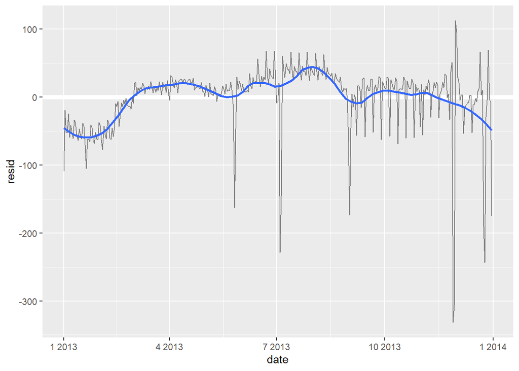

```r
daily %>%
  ggplot(aes(date, resid)) + geom_ref_line(h = 0) + geom_line(color = "grey50") +
  geom_smooth(se = FALSE, span = 0.20)
```

### 19.3.2 주기적인 토요일 효과

일단 토요일 비행 횟수를 정확하게 예측하지 못한 문제가 있다.  
처음에는 데이터를 토요일로 한정해서 알아보자

[figure not shown]

```r
daily %>%
  filter(wday == "Sat") %>%
  ggplot(aes(date, n)) + geom_point() + geom_line() + scale_x_date(
    NULL, date_breaks = "1 month", date_labels = "%b"
  )
```

위 패턴은 여름 휴가로 인해 발생한것으로 추측된다.  
여름휴가는 대부분 6월 초에서 8월 말 사이이고 토요일에 휴가를 떠나도 상관이 없는것같다  
그렇다면 가을보다 봄에 토요일 비행이 많은 이유는?  
미국인에게 가을은 추수감사절과 크리스마스가 있어 휴가를 계획하는것은 일반적이지 않은듯하다  
그렇다면 3개의 학기를 포함하는 학기 변수를 만들고 확인해보자

[figure not shown]

```r
term <- function(date) {
  cut(date, breaks = ymd(20130101, 20130605, 20130825, 20140101),
  labels = c("spring", "summer", "fall")
  )
}

daily <- daily %>%
  mutate(term = term(date))

daily %>%
  filter(wday == "Sat") %>%
  ggplot(aes(date, n, color = term)) +
  geom_point(alpha = 1/3) +
  geom_line() + scale_x_date(
    NULL, date_breaks = "1 month", date_labels = "%b"
  )
```

위 데이터가 다른요일에 어떤 영향을 미치는지 확인하는것은 유용하다

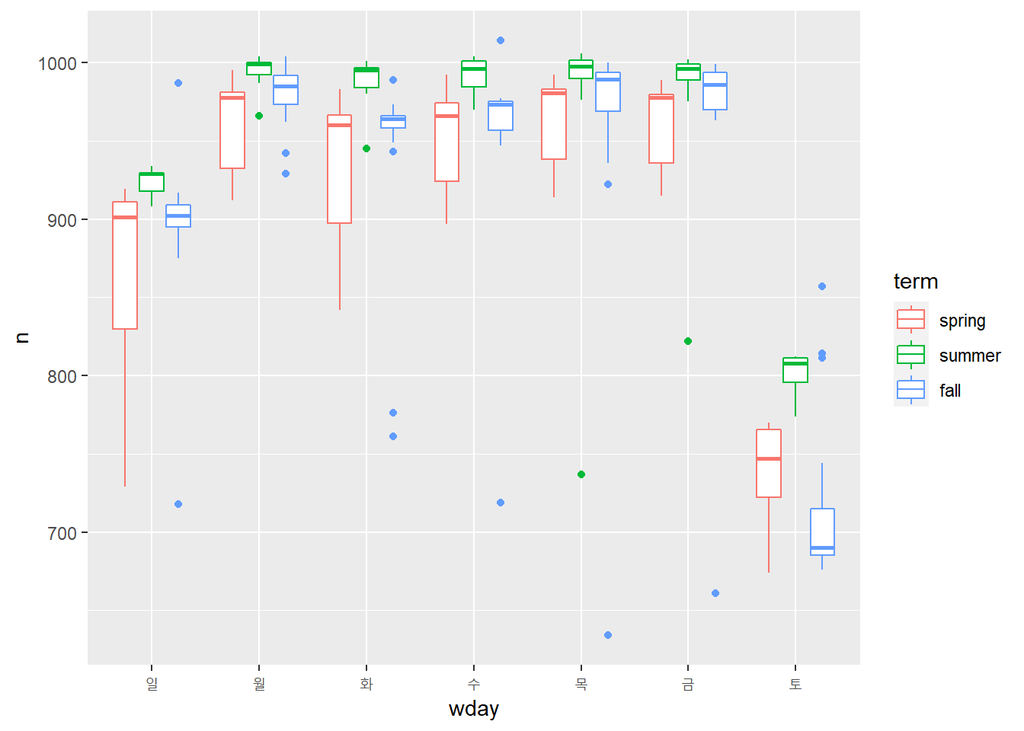

```r
daily %>%
  ggplot(aes(wday, n, color = term)) + geom_boxplot()
```

학기 전반에 변동이 있는것으로 보이므로 각 학기에 대해 별도의 요일 효과를 적용하는 것이 합리적이다  
요일 정보는 모델을 개선시키지만 기대 효과는 낮다

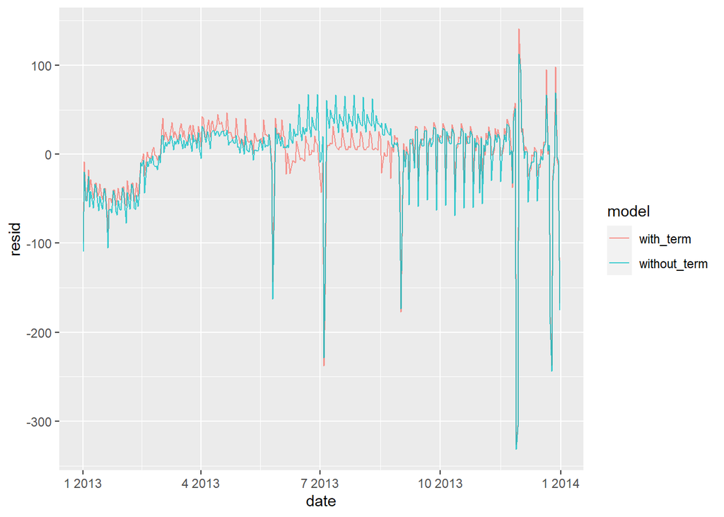

```r
mod1 <- lm(n ~ wday, data = daily)
mod2 <- lm(n ~ wday * term, data = daily)

daily %>%
gather_residuals(without_term = mod1, with_term = mod2) %>%
ggplot(aes(date, resid, color = model)) +
  geom_line(alpha = 0.75)
```

모델로 예측한값을 원래 데이터와 겹쳐그리면 문제를 확인할 수 있다

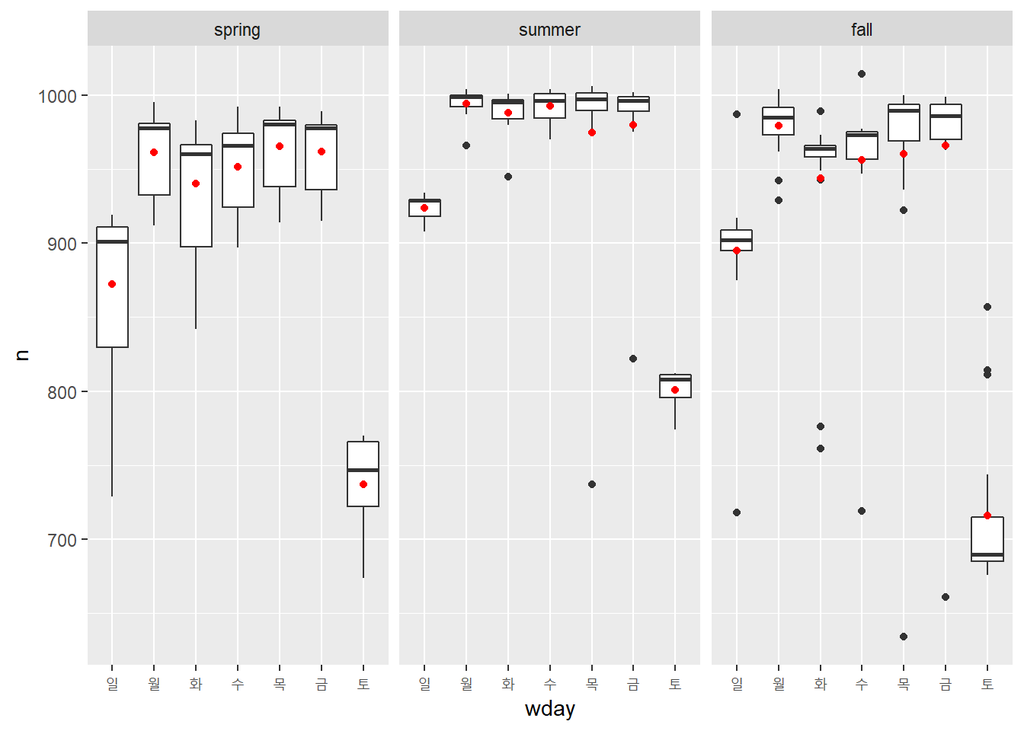

```r
grid <- daily %>%
  data_grid(wday, term) %>%
  add_predictions(mod2, "n")

ggplot(daily, aes(wday,n)) +
  geom_boxplot() + geom_point(data = grid, color = "red") + facet_wrap(~ term)
```

각 학기에 요일을 대입한 결과 조금 더 알기 쉽게 구분이 되었다

모델은 평균 효과를 찾지만 값이 큰 이상값이 많으므로 평균값은 일반값과 멀어진다  
이 문제는 이상값에 영향을 덜 받는 MASS::rlm()을 사용하는 것이다  
이 함수는 이상값이 추정값에 미치는 영향을 줄이고 요일 패턴을 제거하는 모델을 제공한다

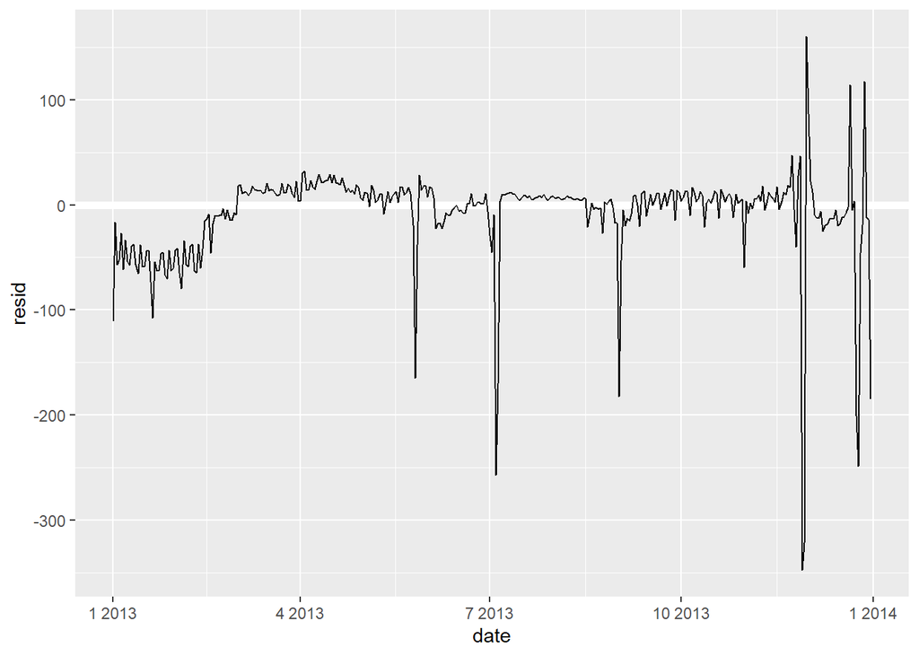

```r
mod3 <- MASS::rlm(n ~ wday * term, data = daily)

daily %>%
  add_residuals(mod3, "resid") %>%
  ggplot(aes(date, resid)) + geom_hline(yintercept = 0, size = 2, color = "white") +
  geom_line()
```

정기적인 추세와 양과 음의 이상값을 훨씬 쉽게 확인 가능하다

### 19.3.3 계산된 변수

두 방법 모두 합리적이다  
변형된 변수를 명시적으로 만드는 것은 작업을 확인하거나 변수를 시각화에 이용하려는 경우 유용하다.  
모델함수에 변형을 포함하면 모델 자체에서 변형되기 때문에 다양한 데이터셋으로 작업하는 경우에 좀 더 쉽게  
사용이 가능하다

### 19.3.4 연중시각 : 다른 접근법

이번에는 모델을 향상하기 위해 도메인 지식을 사용했다  
모델에 명시적인 지식을 포함시키는 방법 대신 다차원의 데이터를 포함하도록 하는 방식도 있다.  
그것은 더 유연한 모델을 사용하여 관심있는 패턴을 포착하는 것이다  
이때 간단한 선형 추세는 적합하지 않기 때문에 1년의 기간에 대해서 매끄러운 곡선을 적합하기 위해  
자연스러운 스플라인을 적용해볼 수 있다

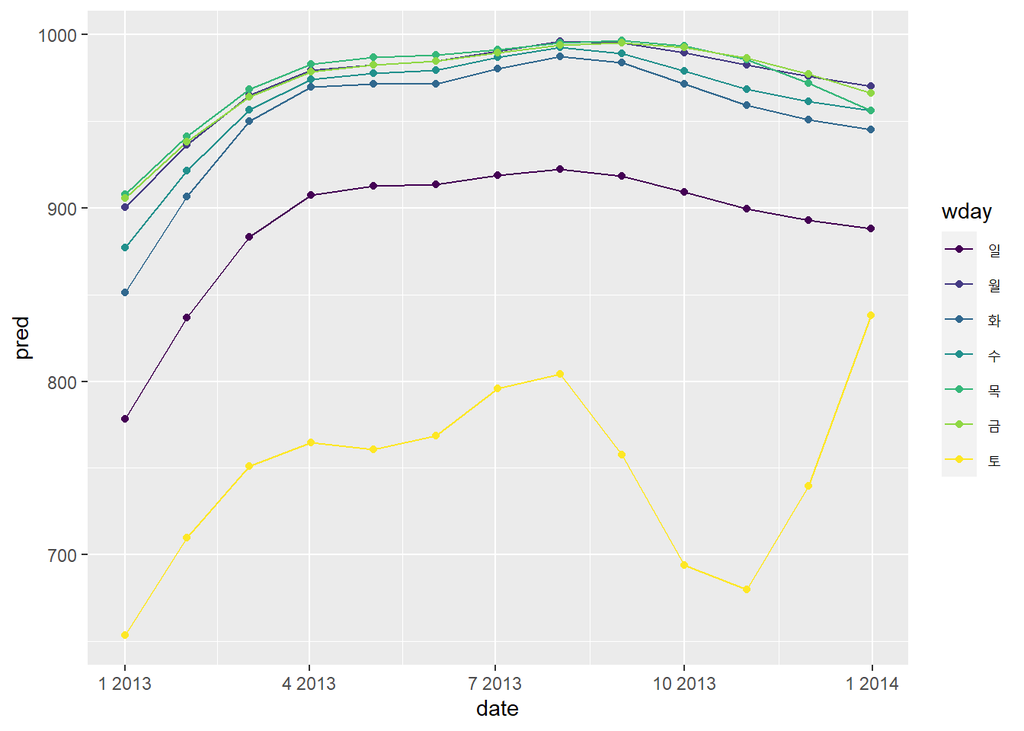

```r
library(splines)
mod <- MASS::rlm(n ~ wday * ns(date, 5), data = daily)

daily %>%
  data_grid(wday, date = seq_range(date, n = 13)) %>%
  add_predictions(mod) %>%
  ggplot(aes(date, pred, color = wday)) + geom_line() + geom_point()
```

토요일의 비행회수가 다른 패턴과 확연히 다르다  
이는 원래 데이터에서도 그랬으니 괜찮다

### 19.4 모델에 대해 더 학습하기

모델링의 겉부분만 살펴보았다.  
이와같은 방법을 사용하면 스스로 데이터 분석 역량을 향상하는데 사용할 수 있는  
간단하고도 범용적인 도구를 얻을 수 있다  
위에서 보았듯 아주 단순한 모델조차 변수 간의 관계를 알아내는 능력에 큰 변화를 가져올 수 있다  
모델링에 대해서 배우는 이번 장은 다른장과 다른방식을 사용했다  
대부분의 책들과 다른 관점에서 모델링에 접근하였고 모델링에 대한 분량이 상대적으로 적다  
모델링은 그 내용만으로 책 한권분량이 나오므로 다른 책들도 읽어보길 이 책에서는 권장하고있다